# Día 2: Modelación de la mortalidad y descomposición de la esperanza de vida

Autor/a

José Manuel Aburto y Ana Cristina Gómez Ugarte Valerio

Fecha de publicación

31 de diciembre de 2025

En esta práctica trabajaremos con dos tareas:

1. Ajustar modelos de mortalidad: Gompertz, Weibull y Heligman-Pollard.
2. Descomponer cambios en esperanza de vida por edad y causa de muerte.

## 1. Preparación de datos

Usaremos datos de mortalidad de la [**Human Mortality Database**](https://www.mortality.org/) (HMD). La HMD ofrece tablas de vida comparables para muchos países.

### Opción 1: descargar directamente desde HMD

Si quieren explorar países además de Estados Unidos, pueden descargar datos directamente desde HMD después de registrarse gratuitamente en https://www.mortality.org/.

```r
# Cargar paquetes
library(tidyverse)
library(HMDHFDplus)
library(MortalityLaws)
library(reshape2)

# Definir credenciales de HMD
myHMDusername <- "your_email@example.com"
myHMDpassword <- "your_password"

# Descargar datos de tabla de vida desde HMD
LT <- readHMDweb(
  CNTRY = "USA",
  item = "fltper_1x1",
  username = myHMDusername,
  password = myHMDpassword
)
```

### Opción 2: cargar desde el archivo local

Para esta práctica ya tenemos descargada una tabla de vida femenina de Estados Unidos.

```r
# Cargar paquetes
library(tidyverse)
library(HMDHFDplus)
library(MortalityLaws)
library(reshape2)
options(scipen = 4) # Evitar notacion cientifica
```

```r
# Codigo del pais
country_code <- "USA"

# Leer archivo local de HMD
data_path <- "USAfltper_1x1.txt"
LT <- readHMD(data_path, fixup = TRUE)

# Revisar la estructura inicial
head(LT)
```

|  | Year | Age | mx | qx | ax | lx | dx | Lx | Tx | ex | OpenInterval |
| --- | --- | --- | --- | --- | --- | --- | --- | --- | --- | --- | --- |
| 1 | 1933 | 0 | 0.05418 | 0.05208 | 0.26 | 100000 | 5208 | 96130 | 6279695 | 62.80 | FALSE |
| 2 | 1933 | 1 | 0.00887 | 0.00883 | 0.50 | 94792 | 837 | 94374 | 6183565 | 65.23 | FALSE |
| 3 | 1933 | 2 | 0.00402 | 0.00402 | 0.50 | 93955 | 377 | 93767 | 6089191 | 64.81 | FALSE |
| 4 | 1933 | 3 | 0.00287 | 0.00287 | 0.50 | 93578 | 268 | 93444 | 5995425 | 64.07 | FALSE |
| 5 | 1933 | 4 | 0.00223 | 0.00223 | 0.50 | 93310 | 208 | 93206 | 5901981 | 63.25 | FALSE |
| 6 | 1933 | 5 | 0.00185 | 0.00185 | 0.50 | 93102 | 172 | 93016 | 5808775 | 62.39 | FALSE |

Veamos cómo han evolucionado los patrones de mortalidad desde el inicio de la serie temporal (1933).

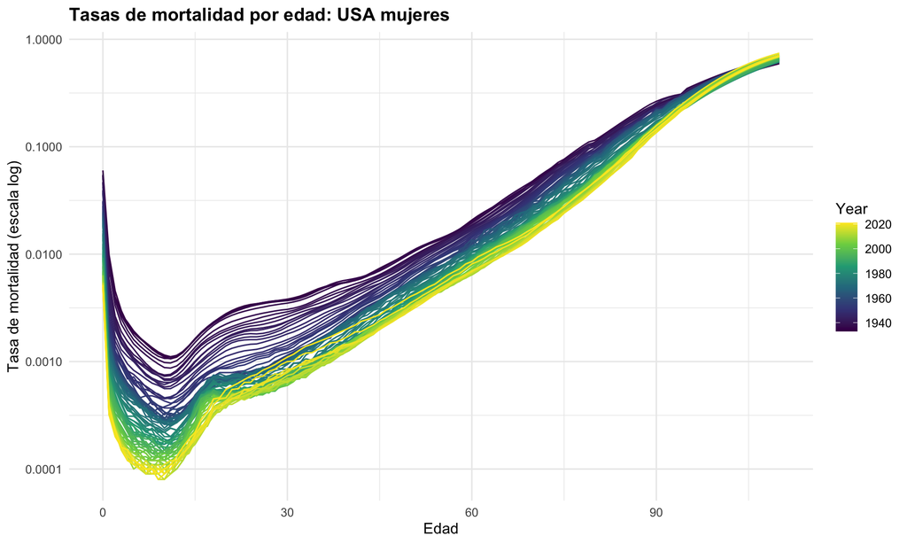

```r
ggplot(data = LT) +
  geom_line(aes(x = Age, y = mx, colour = Year, group = Year)) +
  scale_y_log10() +
  scale_color_viridis_c() +
  labs(
    title = paste("Tasas de mortalidad por edad:", country_code, "mujeres"),
    x = "Edad",
    y = "Tasa de mortalidad (escala log)"
  ) +
  theme_minimal(base_size = 12) +
  theme(
    plot.title = element_text(face = "bold"),
    legend.position = "right"
  )
```

**Pregunta:** ¿Cómo han cambiado el nivel general y la forma de la curva de mortalidad a lo largo del tiempo?

## 2. Modelación de la mortalidad

Ajustaremos tres modelos paramétricos a la mortalidad femenina de Estados Unidos en **1990**. Cada modelo captura una parte distinta de la curva de mortalidad por edad:

- **2.1 Gompertz**: aumento exponencial de la mortalidad adulta (edades 30+).
- **2.2 Weibull**: descenso del riesgo en infancia y niñez (edades 1-10).
- **2.3 Heligman-Pollard**: rango completo de edades, combinando tres componentes.

```r
# Seleccionar año para el analisis
year <- 1990

# Filtrar datos de ese año
LT_year <- LT %>%
  filter(Year == year)
```

### 2.1 Modelo de Gompertz

El **modelo de Gompertz** es uno de los modelos paramétricos de mortalidad más simples y utilizados. Describe la mortalidad adulta como un aumento exponencial:

$$\mu_x = a \cdot e^{bx}$$

donde $\mu_x$ es la fuerza de mortalidad a la edad $x$, $a$ es el nivel basal de mortalidad y $b$ es la tasa de envejecimiento.

Este modelo funciona mejor para edades 30+, donde la mortalidad aumenta de forma casi exponencial. No puede capturar bien los patrones de edades tempranas, como mortalidad infantil/juvenil o el aumento por accidentes en edades jóvenes.

```r
# Preparar datos, edades 30-100
gompertz_data <- LT_year %>%
  filter(Age >= 30, Age <= 100)

# Ajustar modelo de Gompertz
gomp_fit <- MortalityLaw(
  x = gompertz_data$Age,
  mx = gompertz_data$mx,
  law = "gompertz",
  opt.method = "poissonL"
)

# Mostrar parametros
summary(gomp_fit)
```

```
Gompertz model: mu[x] = A exp[Bx]
Fitted values: mx

Call: MortalityLaw(x = gompertz_data$Age, mx = gompertz_data$mx, law = "gompertz",
    opt.method = "poissonL")

Deviance Residuals:
   Min. 1st Qu.  Median    Mean 3rd Qu.    Max.
-0.0148 -0.0012  0.0002  0.0000  0.0004  0.0115

Parameters:
     A      B
0.0004 0.0951

Goodness of fit:
 logLik     AIC     BIC
 2.4898 -0.9797  3.5457

Residual standard error: 0.02822 on 69 degrees of freedom
```

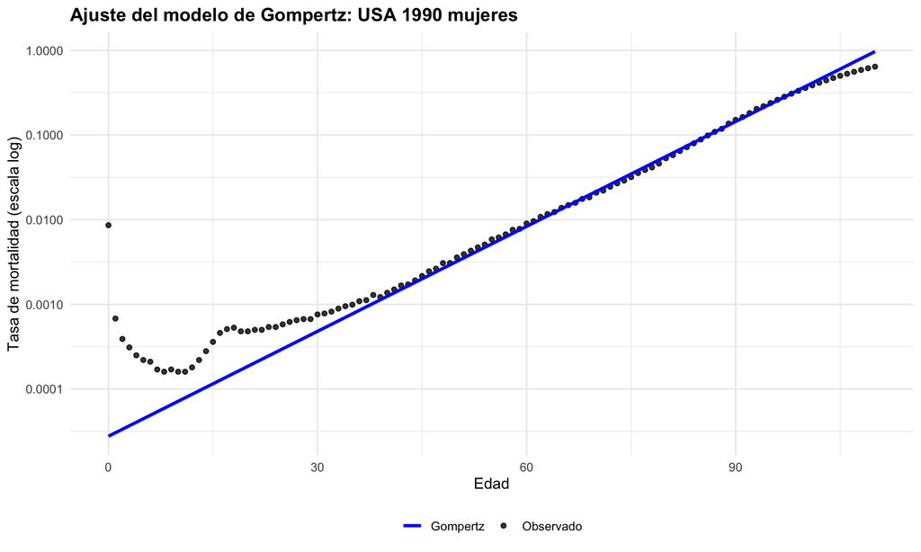

```r
# Predecir en todo el rango de edad
ages_full <- 0:110
gompertz_pred <- predict(gomp_fit, x = ages_full)

# Graficar observado vs ajustado
obs <- LT_year %>% select(Age, mx)
pred <- tibble(Age = ages_full, mx = gompertz_pred)

ggplot() +
  geom_point(
    data = obs, aes(x = Age, y = mx, color = "Observado"),
    size = 1.5, alpha = 0.8
  ) +
  geom_line(
    data = pred, aes(x = Age, y = mx, color = "Gompertz"),
    linewidth = 1.2
  ) +
  scale_y_log10() +
  scale_color_manual(values = c("Observado" = "black", "Gompertz" = "blue")) +
  labs(
    title = paste("Ajuste del modelo de Gompertz:", country_code, year, "mujeres"),
    x     = "Edad",
    y     = "Tasa de mortalidad (escala log)",
    color = NULL
  ) +
  theme_minimal(base_size = 12) +
  theme(
    plot.title      = element_text(face = "bold"),
    legend.position = "bottom"
  )
```

**Preguntas:**

- Interpreten los parámetros estimados.
- ¿En qué rango de edades ajusta bien el modelo y dónde empieza a fallar?

### 2.2 Modelo de Weibull

El **modelo de Weibull** captura la fase decreciente de la mortalidad en la infancia y niñez. Su función de riesgo es:

$$\mu_x = \frac{k}{\lambda}\left(\frac{x}{\lambda}\right)^{k-1}$$

donde $k$ es el **parámetro de forma** y $\lambda$ es el **parámetro de escala**.

El parámetro de forma $k$ determina la dirección del riesgo con la edad:

- $k < 1$: riesgo decreciente, característico de la mortalidad infantil y de la niñez.
- $k = 1$: riesgo constante (distribución exponencial).
- $k > 1$: riesgo creciente, como en procesos similares a Gompertz.

Para mortalidad infantil y de la niñez esperamos $k < 1$: una persona recién nacida enfrenta un riesgo inicial alto que cae rápidamente durante los primeros años de vida. Por eso Weibull complementa a Gompertz: juntos cubren dos segmentos monotónicos de la curva de mortalidad humana.

```r
# Preparar datos, edades 1-10
weibull_data <- LT_year %>%
  filter(Age >= 1, Age <= 10)

# Ajustar modelo de Weibull
weibull_fit <- MortalityLaw(
  x = weibull_data$Age,
  mx = weibull_data$mx,
  law = "weibull",
  opt.method = "poissonL"
)

# Mostrar parametros
summary(weibull_fit)
```

```
Weibull model: mu[x] = 1/sigma * (x/M)^(M/sigma - 1)
Fitted values: mx

Call: MortalityLaw(x = weibull_data$Age, mx = weibull_data$mx, law = "weibull",
    opt.method = "poissonL")

Deviance Residuals:
   Min. 1st Qu.  Median    Mean 3rd Qu.    Max.
-0.0002  0.0000  0.0000  0.0000  0.0001  0.0001

Parameters:
  sigma       M
34.8775  0.0323

Goodness of fit:
 logLik     AIC     BIC
-3.6968 11.3936 11.9987

Residual standard error: 0.0002897 on 8 degrees of freedom
```

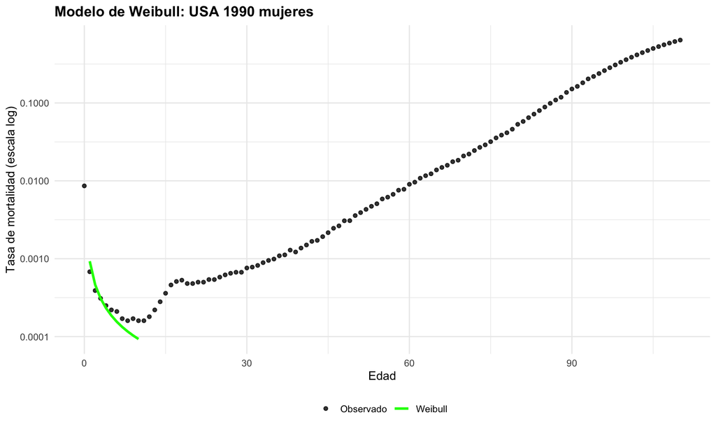

```r
# Predecir para edades 1-10
ages_early <- 1:10
weibull_pred <- predict(weibull_fit, x = ages_early)

# Graficar observado vs ajustado
pred <- tibble(Age = ages_early, mx = weibull_pred)

ggplot() +
  geom_point(
    data = LT_year, aes(x = Age, y = mx, color = "Observado"),
    size = 1.5, alpha = 0.8
  ) +
  geom_line(
    data = pred, aes(x = Age, y = mx, color = "Weibull"),
    linewidth = 1.2
  ) +
  scale_y_log10() +
  scale_color_manual(values = c("Observado" = "black", "Weibull" = "green")) +
  labs(
    title = paste("Modelo de Weibull:", country_code, year, "mujeres"),
    x     = "Edad",
    y     = "Tasa de mortalidad (escala log)",
    color = NULL
  ) +
  theme_minimal(base_size = 12) +
  theme(
    plot.title      = element_text(face = "bold"),
    legend.position = "bottom"
  )
```

**Preguntas:**

- Interpreten los parámetros estimados.
- ¿Por qué excluimos la edad 0 del ajuste?

### 2.3 Modelo de Heligman-Pollard

El modelo de **Heligman-Pollard** (1980) extiende la lógica de Gompertz para capturar patrones de mortalidad en **todas las edades**. Descompone la mortalidad en tres componentes con interpretación demográfica:

$$\frac{q_x}{p_x} = \underbrace{A^{(x+B)^C}}_{\text{(1) infancia}} + \underbrace{D\exp\!\left[-E\!\left(\ln\frac{x}{F}\right)^{\!2}\right]}_{\text{(2) joroba de accidentes}} + \underbrace{GH^x}_{\text{(3) senescencia}}$$

- **Componente 1** $A^{(x+B)^C}$: captura el descenso rápido de la mortalidad infantil y de la niñez (edades 0-10).
- **Componente 2** $D\exp[-E(\ln(x/F))^2]$: captura la joroba de accidentes en adultos jóvenes (edades aproximadas 15-35), como una campana en la escala logarítmica de la edad centrada alrededor de $F$.
- **Componente 3** $GH^x$: captura el aumento exponencial de la mortalidad en edades avanzadas.

El modelo tiene **8 parámetros** (A, B, C, D, E, F, G, H) y se ajusta sobre el rango completo de edades (0-100).

```r
# Preparar datos, edades 0-100
hp_data <- LT_year %>%
  filter(Age >= 0, Age <= 100)

# Ajustar modelo de Heligman-Pollard
hp_fit <- MortalityLaw(
  x = hp_data$Age,
  mx = hp_data$mx,
  law = "HP",
  opt.method = "poissonL"
)

# Mostrar parametros
summary(hp_fit)
```

```
Heligman-Pollard model: q[x]/p[x] = A^[(x + B)^C] + D exp[-E log(x/F)^2] + G H^x
Fitted values: mx

Call: MortalityLaw(x = hp_data$Age, mx = hp_data$mx, law = "HP", opt.method = "poissonL")

Deviance Residuals:
   Min. 1st Qu.  Median    Mean 3rd Qu.    Max.
-0.0048 -0.0002  0.0000  0.0000  0.0001  0.0063

Parameters:
           A            B            C            D            E           F_
4.000000e-04 0.000000e+00 1.340000e-02 1.868885e+26 5.320000e-02 1.131747e+17
           G            H
0.000000e+00 1.136400e+00

Goodness of fit:
 logLik     AIC     BIC
 2.5021 10.9958 31.9167

Residual standard error: 0.01191 on 93 degrees of freedom
```

```r
# Predecir en todo el rango de edad
hp_pred <- predict(hp_fit, x = ages_full)
```

Ahora que los tres modelos están ajustados, los comparamos en el **rango completo de edades**.

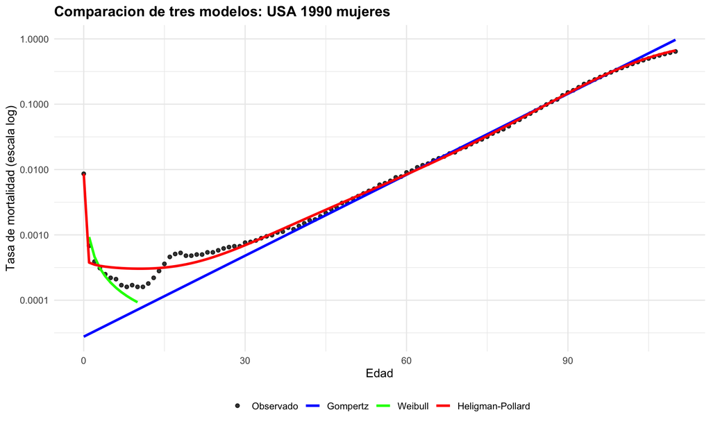

```r
# Construir bases de prediccion separadas para cada modelo
gomp_df <- tibble(Age = ages_full, mx = gompertz_pred)
weib_df <- tibble(Age = ages_early, mx = weibull_pred)
hp_df <- tibble(Age = ages_full, mx = hp_pred)

ggplot() +
  geom_point(
    data = LT_year, aes(x = Age, y = mx, color = "Observado"),
    size = 1.5, alpha = 0.8
  ) +
  geom_line(
    data = gomp_df, aes(x = Age, y = mx, color = "Gompertz"),
    linewidth = 1.2
  ) +
  geom_line(
    data = weib_df, aes(x = Age, y = mx, color = "Weibull"),
    linewidth = 1.2
  ) +
  geom_line(
    data = hp_df, aes(x = Age, y = mx, color = "Heligman-Pollard"),
    linewidth = 1.2
  ) +
  scale_y_log10() +
  scale_color_manual(
    values = c(
      "Observado"          = "black",
      "Gompertz"           = "blue",
      "Weibull"            = "green",
      "Heligman-Pollard"   = "red"
    ),
    breaks = c("Observado", "Gompertz", "Weibull", "Heligman-Pollard")
  ) +
  labs(
    title = paste("Comparacion de tres modelos:", country_code, year, "mujeres"),
    x     = "Edad",
    y     = "Tasa de mortalidad (escala log)",
    color = NULL
  ) +
  theme_minimal(base_size = 12) +
  theme(
    plot.title      = element_text(face = "bold"),
    legend.position = "bottom"
  )
```

**Preguntas:**

- ¿Pueden identificar los tres componentes de la curva de Heligman-Pollard en la gráfica?
- ¿En qué rangos de edad funciona mejor cada modelo y dónde falla?

## 3. Descomposición de la esperanza de vida

La esperanza de vida cambia de forma importante a lo largo del tiempo. Queremos entender **qué grupos de edad** contribuyeron más a ese cambio. Usaremos datos de hombres en Venezuela en 1996 y 2013 para ilustrar el método de descomposición de Arriaga.

### 3.1 Cargar los datos

Los datos corresponden a hombres en Venezuela en 1996 y 2013.

```r
# Cargar datos de mortalidad masculina en Venezuela, 1996 y 2013
load(file = "mortality-modeling-decomposition-data.RData")
```

El objeto `age.specific.mx` contiene tasas de mortalidad específicas por edad.

```r
head(age.specific.mx)
```

|  | sex | year | age | mx |
| --- | --- | --- | --- | --- |
| 1 | 1 | 1996 | 0 | 0.0245173704 |
| 2 | 1 | 1996 | 1 | 0.0015086759 |
| 3 | 1 | 1996 | 5 | 0.0004879040 |
| 4 | 1 | 1996 | 10 | 0.0005411554 |
| 5 | 1 | 1996 | 15 | 0.0019348848 |
| 6 | 1 | 1996 | 20 | 0.0027889940 |

El objeto `cause.age.specific.mx` contiene tasas de mortalidad específicas por edad y causa. Las columnas 1:10 corresponden a:

1. Enfermedades circulatorias
2. Neoplasias
3. Diabetes
4. Homicidio y otras causas violentas
5. Otras causas externas
6. Condiciones del periodo perinatal
7. Enfermedades respiratorias
8. Enfermedades infecciosas
9. Enfermedades digestivas
10. Otras causas

```r
head(cause.age.specific.mx)
```

|  | 1 | 2 | 3 | 4 | 5 | 6 | 7 | 8 | 9 | 10 | sex | year | age |
| --- | --- | --- | --- | --- | --- | --- | --- | --- | --- | --- | --- | --- | --- |
| 1 | 0.00011127943 | 0.00003948625 | 0.0000107689767 | 0.00026922442 | 0.00011845874 | 0.0117130570253 | 0.00180918809 | 0.004587584088 | 0.000215379535 | 0.00564294381 | 1 | 1996 | 0 |
| 2 | 0.00002378115 | 0.00008180714 | 0.0000028537375 | 0.00004946478 | 0.00009892957 | 0.0000000000000 | 0.00021212782 | 0.000390010788 | 0.000025683637 | 0.00062401726 | 1 | 1996 | 1 |
| 3 | 0.00001715870 | 0.00004252374 | 0.0000007460306 | 0.00007311100 | 0.00012085695 | 0.0000007460306 | 0.00002238092 | 0.000024619009 | 0.000008206336 | 0.00017755528 | 1 | 1996 | 5 |
| 4 | 0.00001397350 | 0.00002286572 | 0.0000010162543 | 0.00029039467 | 0.00010137137 | 0.0000000000000 | 0.00001143286 | 0.000009146289 | 0.000005335335 | 0.00008561942 | 1 | 1996 | 10 |
| 5 | 0.00006243906 | 0.00005880888 | 0.0000094384625 | 0.00103895691 | 0.00042618289 | 0.0000000000000 | 0.00003484971 | 0.000053726633 | 0.000029767459 | 0.00022071482 | 1 | 1996 | 15 |
| 6 | 0.00013684845 | 0.00010744300 | 0.0000282744729 | 0.00117621807 | 0.00065483679 | 0.0000000000000 | 0.00007012069 | 0.000222802847 | 0.000048632093 | 0.00034381759 | 1 | 1996 | 20 |

### 3.2 Cargar la función de tabla de vida

Para descomponer la diferencia entre esperanzas de vida necesitamos construir tablas de vida a partir de las tasas de mortalidad en `age.specific.mx`. El archivo `funciones-dia-02.R` contiene una función de tabla de vida y etiquetas útiles para las gráficas.

```r
# Cargar la funcion de tabla de vida
source("funciones-dia-02.R")
```

Podemos revisar nuestra función de tabla de vida:

```r
LifeTable_function
```

```
function (nmx = mx, age = c(0, 1, seq(5, 85, 5)), nax = NULL)
{
    n <- c(diff(age), 999)
    if (is.null(nax)) {
        nax <- 0.5 * n
    }
    nqx <- (n * nmx)/(1 + (n - nax) * nmx)
    nqx <- c(nqx[-length(nqx)], 1)
    nqx[nqx > 1] <- 1
    npx <- 1 - nqx
    lx <- cumprod(c(1, npx))
    ndx <- -diff(lx)
    lxpn <- lx[-1]
    nLxpn <- n * lxpn + ndx * nax
    nLx <- c(nLxpn[-length(nLxpn)], lxpn[length(lxpn) - 1]/nmx[length(nmx)])
    Tx <- rev(cumsum(rev(nLx)))
    lx <- lx[1:length(age)]
    ex <- Tx/lx
    data.frame(cbind(nmx, age, nax, npx, lx, nLx, Tx, ex))
}
```

Los parámetros principales son:

- `nmx`: vector de tasas de mortalidad, usualmente aproximadas con defunciones / población a mitad de año.
- `age`: vector con la edad inferior del grupo de edad.
- `nax`: vector con valores de `nax`. Si no se provee, asignamos la mitad de la longitud del intervalo.

### 3.3 Construir tablas de vida para cada año

```r
lifetable.1996 <- LifeTable_function(
  nmx = age.specific.mx[age.specific.mx$year %in% 1996, ]$mx,
  age = age.specific.mx[age.specific.mx$year %in% 1996, ]$age
)

head(lifetable.1996)
```

|  | nmx | age | nax | npx | lx | nLx | Tx | ex |
| --- | --- | --- | --- | --- | --- | --- | --- | --- |
| 1 | 0.0245173704 | 0 | 0.5 | 0.9757795 | 1.0000000 | 0.9878898 | 69.33658 | 69.33658 |
| 2 | 0.0015086759 | 1 | 2.0 | 0.9939835 | 0.9757795 | 3.8913765 | 68.34869 | 70.04522 |
| 3 | 0.0004879040 | 5 | 2.5 | 0.9975635 | 0.9699087 | 4.8436355 | 64.45732 | 66.45710 |
| 4 | 0.0005411554 | 10 | 2.5 | 0.9972979 | 0.9675455 | 4.8311914 | 59.61368 | 61.61331 |
| 5 | 0.0019348848 | 15 | 2.5 | 0.9903721 | 0.9649311 | 4.8014298 | 54.78249 | 56.77348 |
| 6 | 0.0027889940 | 20 | 2.5 | 0.9861516 | 0.9556408 | 4.7451190 | 49.98106 | 52.30109 |

```r
lifetable.2013 <- LifeTable_function(
  nmx = age.specific.mx[age.specific.mx$year %in% 2013, ]$mx,
  age = age.specific.mx[age.specific.mx$year %in% 2013, ]$age
)

head(lifetable.2013)
```

|  | nmx | age | nax | npx | lx | nLx | Tx | ex |
| --- | --- | --- | --- | --- | --- | --- | --- | --- |
| 1 | 0.0165565677 | 0 | 0.5 | 0.9835794 | 1.0000000 | 0.9917897 | 70.99212 | 70.99212 |
| 2 | 0.0006254993 | 1 | 2.0 | 0.9975011 | 0.9835794 | 3.9294018 | 70.00033 | 71.16897 |
| 3 | 0.0003114802 | 5 | 2.5 | 0.9984438 | 0.9811215 | 4.9017906 | 66.07093 | 67.34224 |
| 4 | 0.0004158072 | 10 | 2.5 | 0.9979231 | 0.9795947 | 4.8928873 | 61.16914 | 62.44331 |
| 5 | 0.0030976117 | 15 | 2.5 | 0.9846310 | 0.9775602 | 4.8502407 | 56.27625 | 57.56806 |
| 6 | 0.0049095345 | 20 | 2.5 | 0.9757500 | 0.9625361 | 4.7543265 | 51.42601 | 53.42762 |

La esperanza de vida al nacer en 1996 y 2013 fue:

```r
lifetable.1996$ex[1]
```

```
[1] 69.33658
```

```r
lifetable.2013$ex[1]
```

```
[1] 70.99212
```

```r
# Diferencia en esperanza de vida
big.delta <- lifetable.2013$ex[1] - lifetable.1996$ex[1]

big.delta
```

```
[1] 1.655535
```

### 3.4 Descomposición por edad: método de Arriaga

Seguimos el algoritmo descrito en Arriaga (1984):

$$_n\Delta_x = \frac{\ell_x^1}{\ell_0^1}\left(\frac{_nL_x^2}{\ell_x^2} - \frac{_nL_x^1}{\ell_x^1}\right) + \frac{T_{x+n}^2}{\ell_0^1}\left(\frac{\ell_x^1}{\ell_x^2} - \frac{\ell_{x+n}^1}{\ell_{x+n}^2}\right)$$

**Paso 1: obtener la información necesaria de las tablas de vida**

```r
# Extraer componentes de la tabla de vida
l1 <- lifetable.1996$lx
l2 <- lifetable.2013$lx

L1 <- lifetable.1996$nLx
L2 <- lifetable.2013$nLx

T1 <- lifetable.1996$Tx
T2 <- lifetable.2013$Tx

LAG <- length(l1)
```

**Paso 2: calcular componentes directos e indirectos**

```r
DE <- (l1 / l1[1]) * ((L2 / l2) - (L1 / l1))

IE <- (T2[-1] / l1[1]) * ((l1[-LAG] / l2[-LAG]) - (l1[-1] / l2[-1]))

# Agregar 0: no hay efecto indirecto para el ultimo grupo de edad
IE <- c(IE, 0)
```

**Paso 3: sumar los componentes para obtener la contribución específica por edad y verificar contra el cambio total**

```r
# Sumar efectos directos e indirectos
ALL <- DE + IE

# Verificacion: la suma debe ser igual a big.delta
big.delta
```

```
[1] 1.655535
```

```r
# Suma de contribuciones especificas por edad
sum(ALL)
```

```
[1] 1.655535
```

**Paso 4: graficar e interpretar resultados**

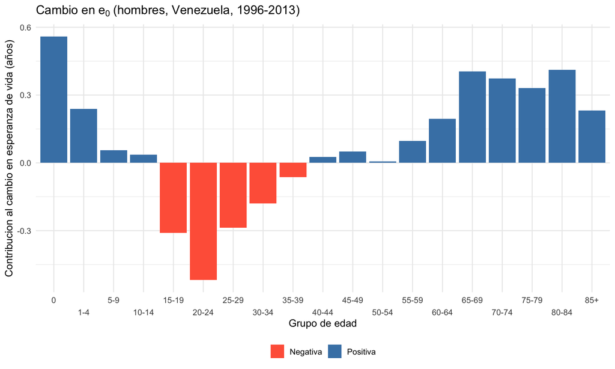

```r
ggplot() +
  geom_bar(
    aes(
      x    = factor(c(0, 1, seq(5, 85, 5)), labels = age_names),
      y    = ALL,
      fill = ALL > 0
    ),
    stat = "identity"
  ) +
  scale_fill_manual(
    values = c("TRUE" = "steelblue", "FALSE" = "tomato"),
    labels = c("TRUE" = "Positiva", "FALSE" = "Negativa"),
    name   = NULL
  ) +
  scale_x_discrete(guide = guide_axis(n.dodge = 2)) +
  labs(
    title = bquote("Cambio en" ~ e[0] ~ "(hombres, Venezuela, 1996-2013)"),
    x     = "Grupo de edad",
    y     = "Contribucion al cambio en esperanza de vida (años)"
  ) +
  theme_minimal(base_size = 12) +
  theme(
    plot.title      = element_text(face = "bold"),
    legend.position = "bottom"
  )
```

**Preguntas:**

- ¿Qué grupos de edad contribuyeron más al aumento o descenso de la esperanza de vida?
- ¿Qué revelan estos patrones sobre las tendencias de mortalidad en Venezuela entre 1996 y 2013?

### 3.5 Extensión: descomposición por edad y causa

Para extender la descomposición a causas de muerte, recordemos la ecuación de las diapositivas:

$$_n\Delta_x^i = _n\Delta_x \frac{_nm_{x,i}^2 - _nm_{x,i}^1}{_nm_{x}^2 - _nm_{x}^1}$$

El primer elemento, $_n\Delta_x$, ya lo tenemos en el objeto `ALL` y fue graficado arriba. El denominador es simplemente la diferencia de tasas de mortalidad específicas por edad:

```r
# Cambio en tasas de mortalidad especificas por edad (denominador)
denominator <- lifetable.2013$nmx - lifetable.1996$nmx
```

Ahora necesitamos la diferencia entre la mortalidad específica por edad y causa en los dos periodos. Esta información está en el objeto `cause.age.specific.mx`. Podemos hacer esta operación usando matrices.

```r
# Cambio en tasas de mortalidad especificas por edad y causa (numerador)
matrix.2013 <- cause.age.specific.mx[cause.age.specific.mx$year %in% 2013, 1:10]
matrix.1996 <- cause.age.specific.mx[cause.age.specific.mx$year %in% 1996, 1:10]
numerator <- matrix.2013 - matrix.1996
```

Ahora tenemos todos los ingredientes para calcular la descomposición por edad y causa:

```r
age.cause.decomposition <- ALL * (numerator / denominator)

# Renombrar columnas
colnames(age.cause.decomposition) <- cause_names

# Agregar columna de grupo de edad
age.cause.decomposition$age.group <- factor(c(0, 1, seq(5, 85, 5)), labels = age_names)

# Convertir a formato largo
age.cause.decomposition.long <- melt(
  data = age.cause.decomposition,
  id.vars = "age.group",
  variable.name = "Causa",
  value.name = "Contribucion"
)

head(age.cause.decomposition.long)
```

|  | age.group | Causa | Contribucion |
| --- | --- | --- | --- |
| 1 | 0 | Enfermedades circulatorias | 0.0042980914 |
| 2 | 1-4 | Enfermedades circulatorias | 0.0042811748 |
| 3 | 5-9 | Enfermedades circulatorias | 0.0040094764 |
| 4 | 10-14 | Enfermedades circulatorias | 0.0029646728 |
| 5 | 15-19 | Enfermedades circulatorias | 0.0046117807 |
| 6 | 20-24 | Enfermedades circulatorias | -0.0008786136 |

Finalmente, grafiquemos los resultados:

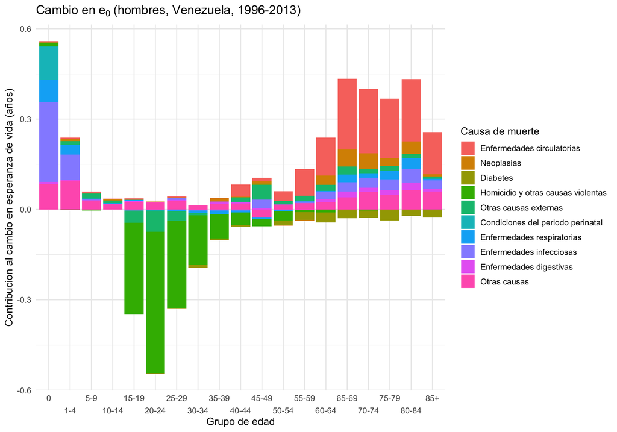

```r
ggplot(
  data = age.cause.decomposition.long,
  aes(x = age.group, y = Contribucion, fill = Causa)
) +
  geom_bar(stat = "identity", position = "stack") +
  scale_x_discrete(guide = guide_axis(n.dodge = 2)) +
  labs(
    title = bquote("Cambio en" ~ e[0] ~ "(hombres, Venezuela, 1996-2013)"),
    x     = "Grupo de edad",
    y     = "Contribucion al cambio en esperanza de vida (años)",
    fill  = "Causa de muerte"
  ) +
  theme_minimal(base_size = 12) +
  theme(
    plot.title      = element_text(face = "bold"),
    legend.position = "right"
  )
```

**Pregunta:** ¿Qué causas de muerte impulsaron el descenso en la esperanza de vida y en qué edades tuvieron mayor impacto?